# Lab 3: Graphics and descriptive statistics using R

### This assignment is due at 11:59 p.m. the day of lab.

Please submit your lab report by renaming this R Markdown file as “Lab2LastnameFirstname.Rmd” **(please replace Lastname and Firstname with your last and first names, respectively** and uploading it to the appropriate Lab 3 submission link on Chalk. Please provide answers in this document in the form of plain text and

```r
code chunks #with comments when necessary
```

to all green questions.

## Graphics and Plotting

R is a fantastic language for data-related graphics. Let’s start to make some simple graphics of our own. First, we will use the built-in function `runif()` to create two vectors of equal length. `runif()` provides us with random numbers sampled from a uniform distribution between 0 and 1. The numerical argument passed to runif determines how many numbers it should sample. For example, try running `runif(10)` and look at the output. You should see 10 numbers distributed between 0 and 1. Because this command returns random numbers, if you run `runif(10)` again, you will see a different set of 10 numbers between 0 and 1. Next, try assigning the output to a vector as follows:

```r
x <- runif(100)
y <- runif(100)
```

To get a simple scatter plot, we can enter the following command:

```r
plot(x, y)
```

This plot should appear in the bottom right-hand corner of your Rstudio window. What are the axis names? Let’s try using variables that are not called x and y. R allows us to explicitly add names to the plot, add a title, and even change the color of our points. For example

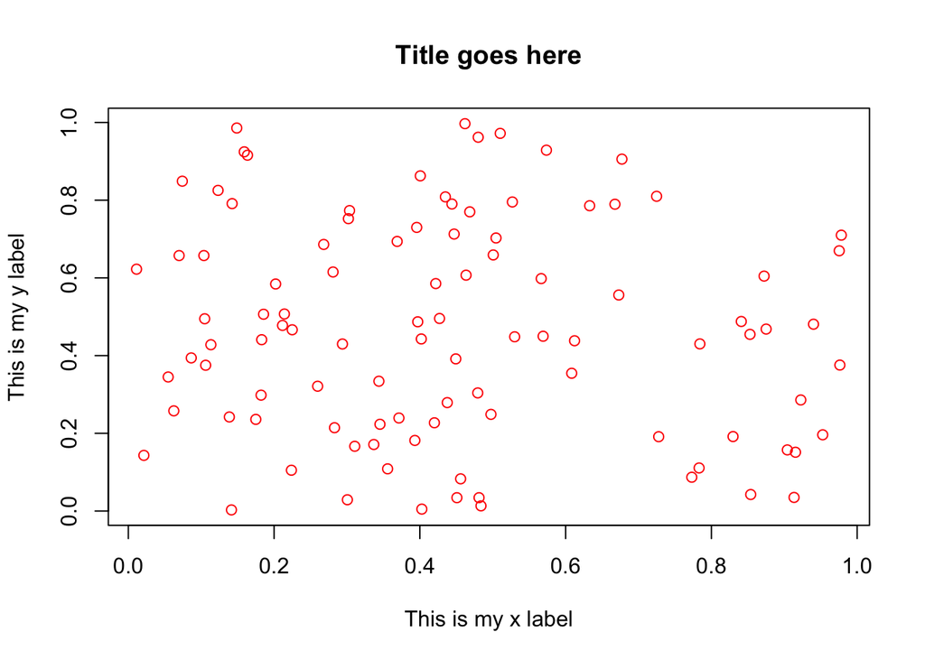

```r
plot(x, y, xlab = "This is my x label", ylab = "This is my y label", col = "red", main = "Title goes here")
```

There are lots of different colors that we can use in our graphs - red, green, purple, salmon, darkslateblue, etc. A convenient reference list of color names can be found at http://www.stat.columbia.edu/~tzheng/files/Rcolor.

Often you will want to plot two datasets on the same figure. After plotting the first dataset with the `plot()` function, you can add further data (“points”) to the plot with the function `points()`. **`points()` has the same syntax as `plot()`**, except that you don’t need to specify the axis labels and the main title again.

1. Using `plot()` and `points()`, plot TWO different datasets (each data set should have two variables) on the same graph of 75 number pairs drawn from the uniform distribution in DIFFERENT colors (show the commands you used in your script). Comment briefly on the distribution of the two datasets relative to each other.

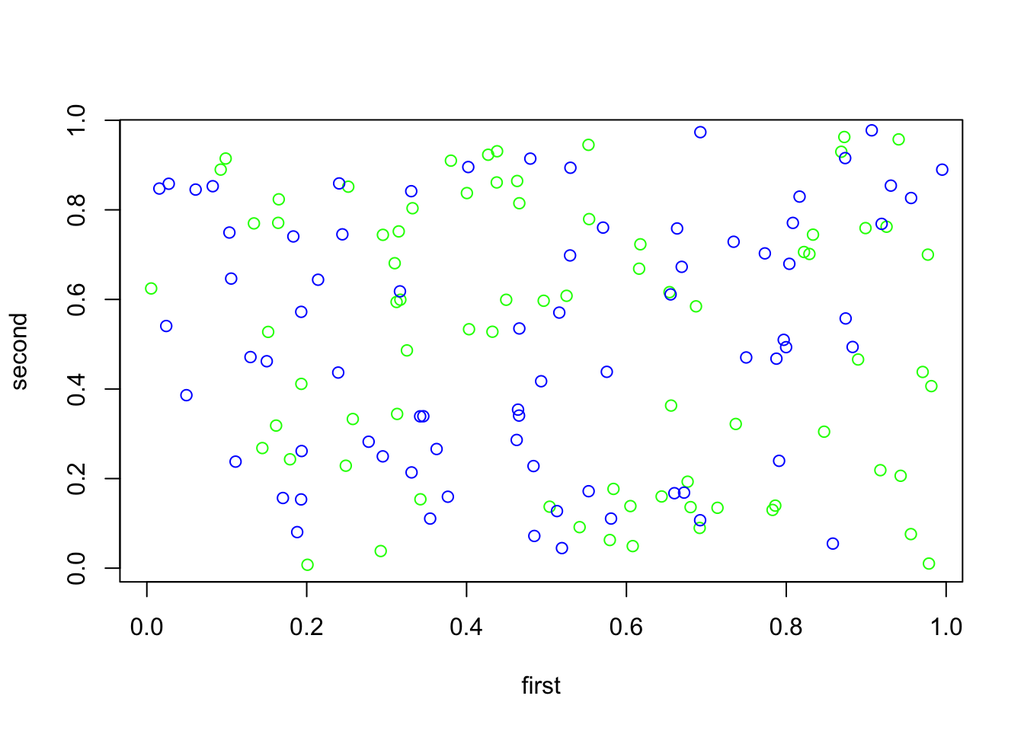

```r
first<-runif(75)
second <- runif(75)
third <- runif(75)
fourth <- runif(75)

plot(first,second, col="green")
points(third,fourth, col = "blue")
```

```r
#both the datasets are relatively very spread out, and a general line of best fit cannot be placed to accurately represent the data. Describes a uniform distribution as all the data points are very spread out, and not shaped like a bell curve (which would be a normal distribution).
```

2. Based on your knowledge about `runif()`, what does the command `rnorm()` do? Try plotting TWO different datasets (each data set should have two variables) of 75 number pairs drawn from the normal distribution in DIFFERENT colors and show the commands you used in your script. Comment briefly on the distribution of the two datasets relative to each other.

The command rnorm(n) takes a normal distribution and returns a sample of n random numbers.

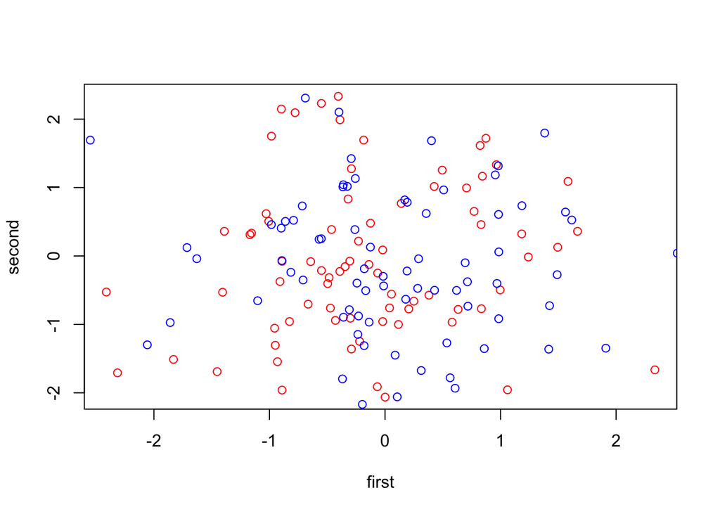

```r
first<-rnorm(75)
second <- rnorm(75)
third <- rnorm(75)
fourth <- rnorm(75)

plot(first,second, col="red")
points(third,fourth, col = "blue")
```

```r
#both the datasets are still relatively spread out, but with the use of the rnorm command, the data points are closer together than with the use of the runif command.  This describes a normal distribution(shape of a bell curve, which explains why the data points are a lot more closer together).
```

Another plotting function in R is `hist()` (introduced in last week’s lab), which takes in one numerical vector and plots a histogram.

3. Use `hist()` to create histograms for a vector consisting of 9 numbers generated from the uniform distribution. Be sure each axis has a sensible label and the plot has an appropriate title. Next, create 3 more histograms for vectors consisting of 90, 900, and then 9000 numbers generated from the uniform distribution. How does the distribution change as you increase the numbers?

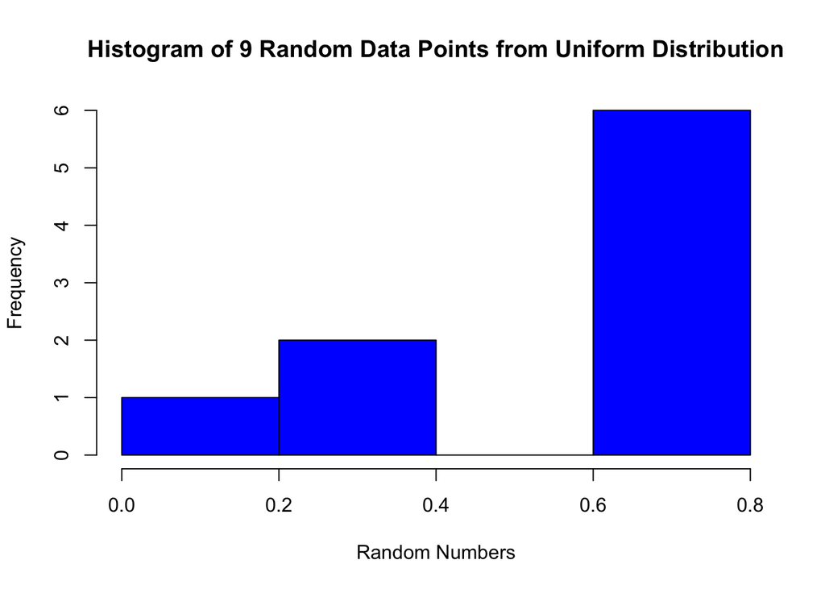

```r
dataSetOne <- runif(9)
hist(dataSetOne, main="Histogram of 9 Random Data Points from Uniform Distribution", xlab="Random Numbers", col="blue")
```

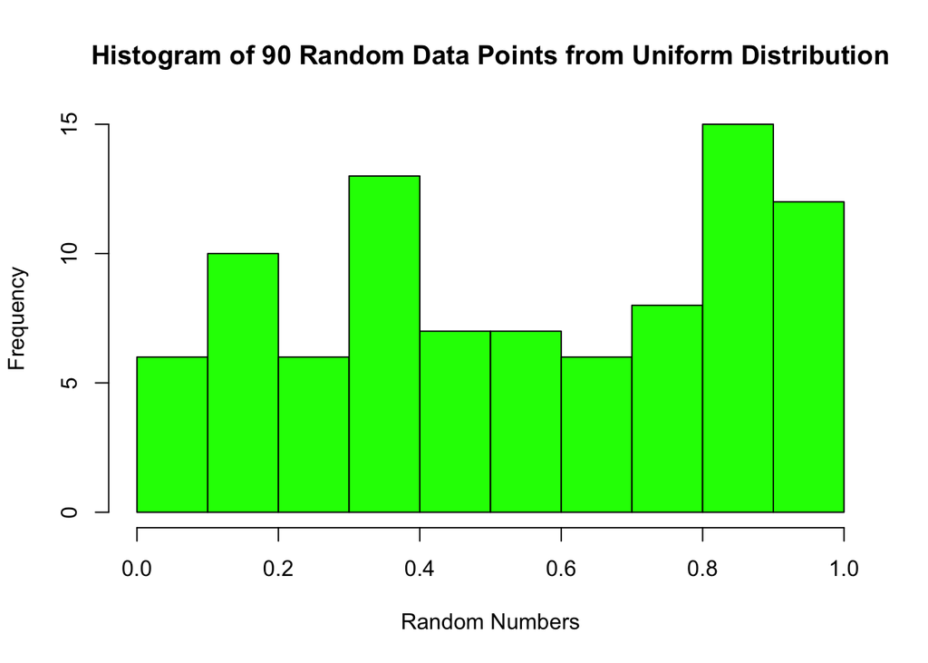

```r
dataSetTwo <- runif(90)
dataSetThree <- runif(900)
dataSetFour <- runif(9000)

hist(dataSetTwo, main="Histogram of 90 Random Data Points from Uniform Distribution", xlab="Random Numbers", col="green")
```

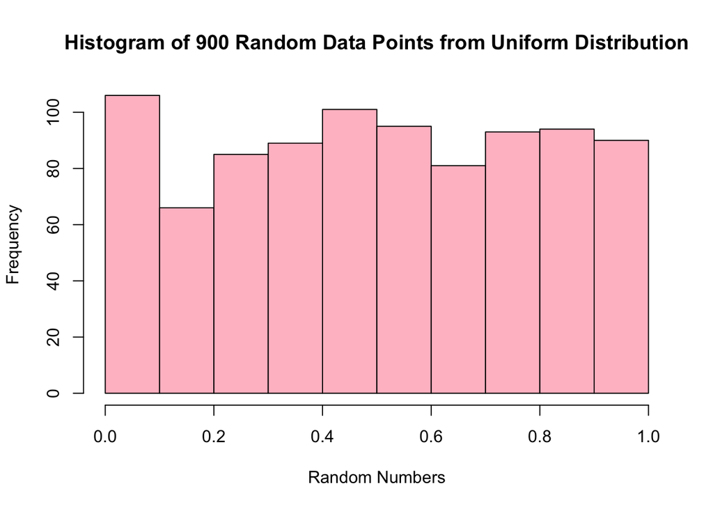

```r
hist(dataSetThree, main="Histogram of 900 Random Data Points from Uniform Distribution", xlab="Random Numbers", col="pink")
```

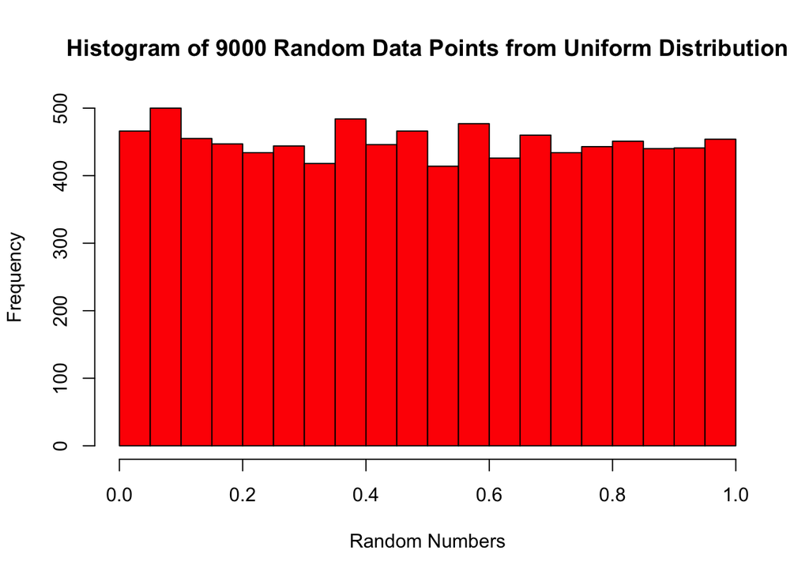

```r
hist(dataSetFour, main="Histogram of 9000 Random Data Points from Uniform Distribution", xlab="Random Numbers", col="red")
```

```r
# as you increase the numbers, the frequency of each bar increases. Shape of the histogram stays relatively similar as you increase the parameter of runif. You can say that uniformity increases as you increase the numbers.
```

4. Repeat question 3 for numbers generated from the normal distribution.

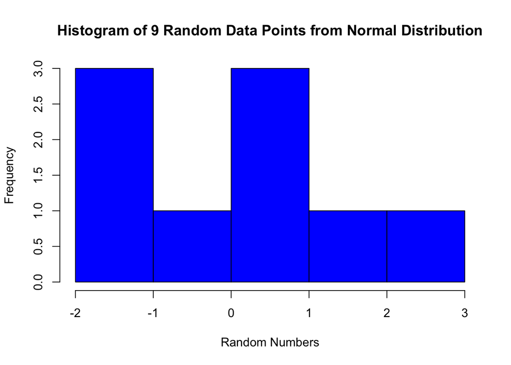

```r
dataSetOne <- rnorm(9)
hist(dataSetOne, main="Histogram of 9 Random Data Points from Normal Distribution", xlab="Random Numbers", col="blue")
```

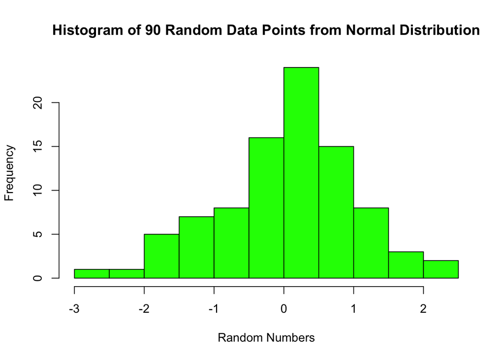

```r
dataSetTwo <- rnorm(90)
dataSetThree <- rnorm(900)
dataSetFour <- rnorm(9000)

hist(dataSetTwo, main="Histogram of 90 Random Data Points from Normal Distribution", xlab="Random Numbers", col="green")
```

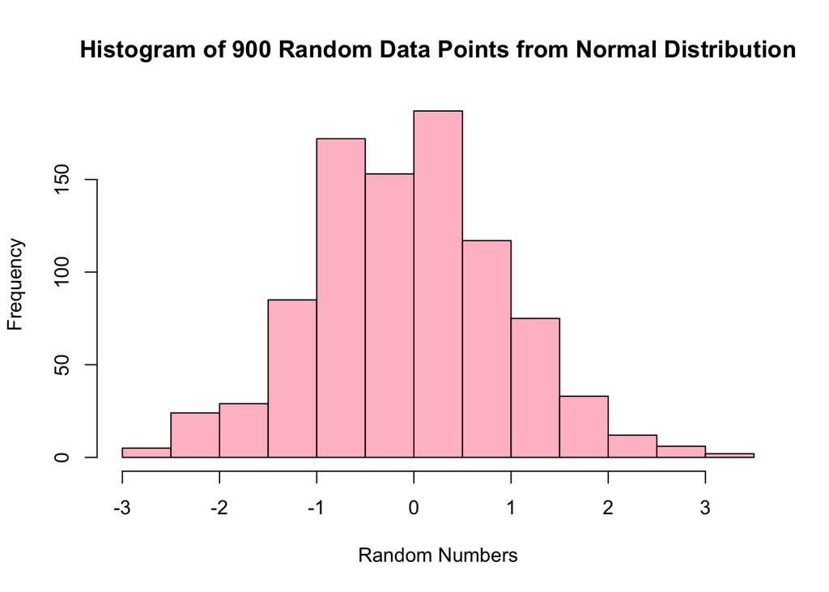

```r
hist(dataSetThree, main="Histogram of 900 Random Data Points from Normal Distribution", xlab="Random Numbers", col="pink")
```

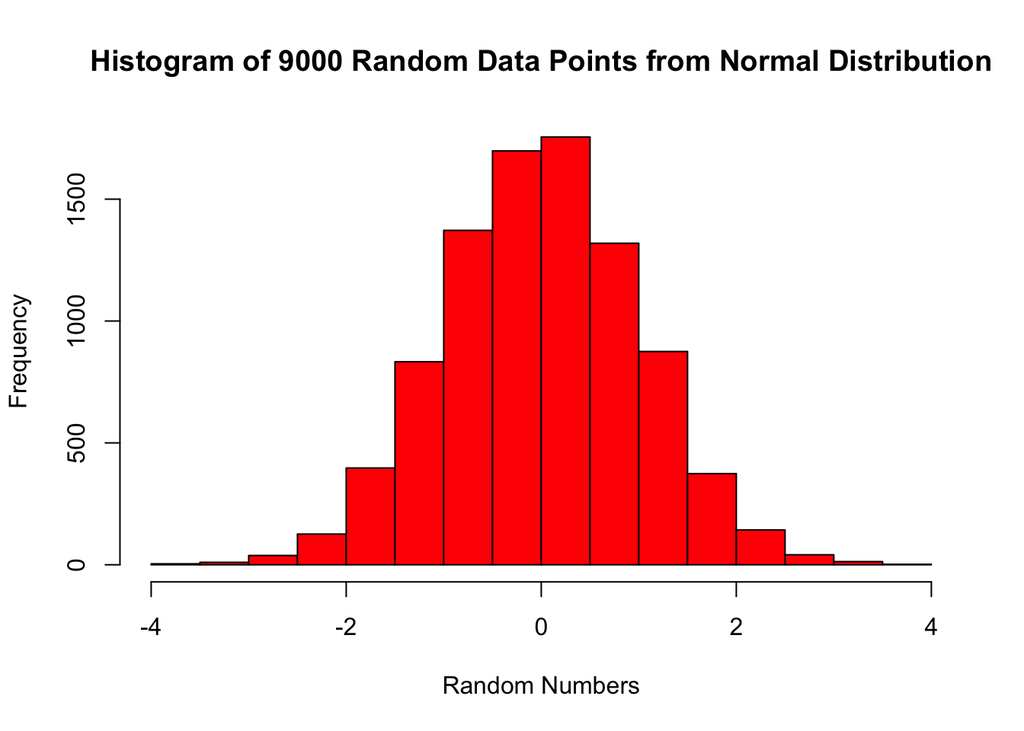

```r
hist(dataSetFour, main="Histogram of 9000 Random Data Points from Normal Distribution", xlab="Random Numbers", col="red")
```

```r
# as you increase the numbers, the frequency of each bar still increase, and the histogram becomes more and more symmetric. You can say that as you increase the numbers, the histogram gets more and more close to a perfect normal distribution.
```

Remember what you have learned here, as we’ll be performing more plotting later in lab!

## Sampling from distributions

The file *protein_data.csv*, which is provided to you in the downloaded lab file, contains the length of the amino acid chain for all the known protein structures with sequence percentage identity of less than 25% (i.e. dissimilar proteins).

5. This protein data was obtained from the Protein Data Bank (PDB) at http://www.rcsb.org/pdb/home/home.do. Follow this link to find the number of distinct protein sequences the database contains and the number of human sequences it contains (hint: you can find this information on PDB’s homepage) and provide the number below.

The number of distinct protein sequences is 139,631 and the number of human protein sequences is 39,209, according to a pie chart on the website link above.

Just as you did in week 2, go to the session tab and set your working directory to the folder you saved the file in. If it is in the same folder, then you can set your working directory the the Source File Location. We need to read the *protein_data.csv* file into R with the `read.csv()` function and **assign it to a variable**. Let’s name the data set `proteinData`. This command will look like:

```r
proteinData <- read.csv("protein_data.csv", header = TRUE, stringsAsFactors = FALSE)
```

This command tells R to read the csv (comma separated value) file that we have saved in our working directory. The parameter `header = TRUE` tells R that the first row of the file just has the names of the variables and should be treated as a header, not as actual data. The parameter `stringsAsFactors = FALSE` tells R to load in columns with character data as familiar character vectors instead of as a compressed format called a factor. We will examine factors later on.

The data gets loaded into R as an object called a **data frame**. A data frame is like a vector in that it can store many pieces of data under one variable name, but it differs in a few key ways. First, a data frame is a **multi-dimensional array**, which means that instead of just having its elements arranged in a single line, **a data frame can have multiple rows and columns**. We can inspect the structure of our new object by using the function `head()` to print the first six rows of `proteinData` to the console:

```r
head(proteinData)
```

```
  protein.IDs length
1        2H0A    276
2        3MFX    387
3        1KQ6    141
4        4NWB    278
5        4XUU    676
6        3OQB   3064
```

From this output, we can see that proteinData is structured as an array of two columns, which are labeled “protein.IDs” and “length”. A few useful functions for data frames are `nrow()` and `ncol()`. Supplying these commands with a data frame as their argument will return the number of rows and columns in that data frame, respectively. For example

```r
ncol(proteinData)
```

```
[1] 2
```

6. How many rows does the data frame `proteinData` contain?

```r
print(paste("The data frame contains",nrow(proteinData),"rows."))
```

```
## [1] "The data frame contains 10798 rows."
```

We can see the names of the columns from our `head()` output above, but to obtain the column names as a manipulable character vector, we can use the command `colnames()`. For our data frame:

```r
colnames(proteinData)
```

```
[1] "protein.IDs" "length"
```

This tells us that our data frame has two columns, one containing the protein IDs and the other containing the length of the protein (corresponding the the number of amino acid residues in the protein).

Here’s a histogram of all the protein lengths.

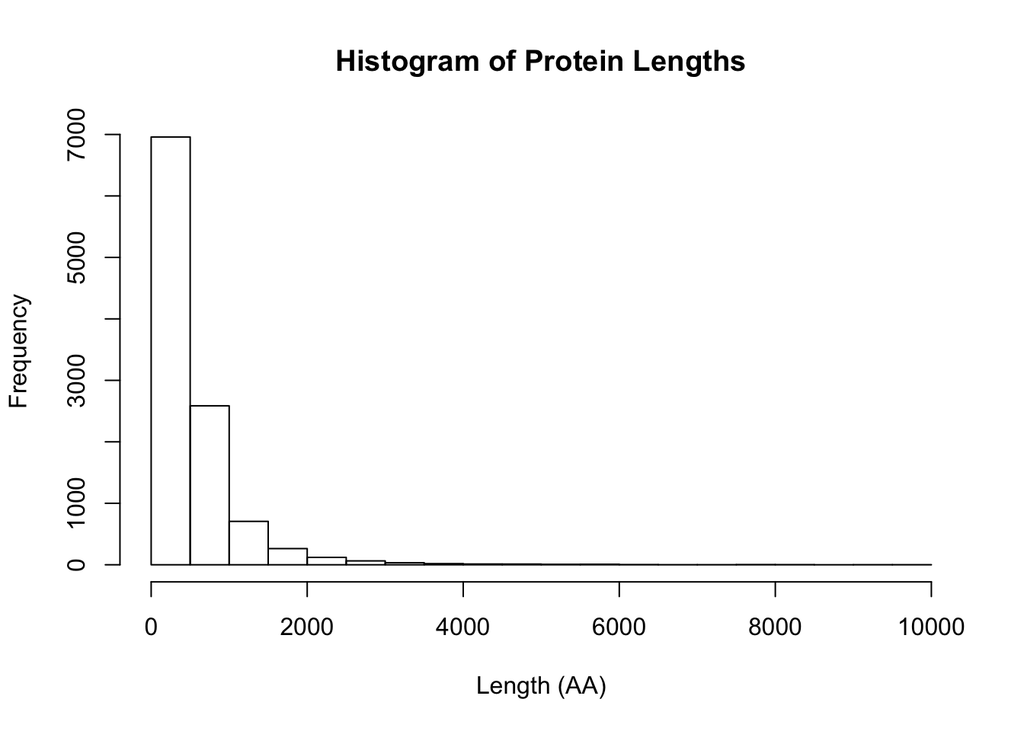

b. Next, reassign the data from the `length` column in the `proteinData` data frame to a vector called `proteinDataVec`. Use the built-in function `length()` to show that the new vector contains the same number of elements as `proteinData` contains rows (show your commands).

```r
proteinDataVec <- proteinData$length

if (length(proteinDataVec) == nrow(proteinData)){
  print("Same value obtained!")
}else{
  print("Same value NOT obtained!")
}
```

```
## [1] "Same value obtained!"
```

8. What is the mean residue length of all of the proteins (i.e. the true mean of the population)? What is the standard deviation of the protein population? What is the range of the protein population (use your function from Lab 2)?

```r
#COPIED MY FUNCTION FROM LAB 2 HERE.
myRange <- function(vec){
  answerVec <- c(min(vec),max(vec))
  return(answerVec)
}

print(paste("True mean of the population:",mean(proteinData$length)))
```

```
## [1] "True mean of the population: 545.394239674014"
```

```r
print(paste("Standard Deviation of the Protein:",sd(proteinData$length)))
```

```
## [1] "Standard Deviation of the Protein: 594.628575492025"
```

```r
ans<- myRange(proteinData$length)
print(paste("Range of the protein population:",ans[1],"to",ans[2]))
```

```
## [1] "Range of the protein population: 40 to 9900"
```